# regression

```r
library(tidyverse)
library(GGally) # for scatterplot matrices
library(modelr) # for convenient models manipulation
```

```r
data(mpg)
head(mpg)
```

```
## # A tibble: 6 x 11
##   manufacturer model displ  year   cyl trans drv     cty   hwy fl    class
##   <chr>        <chr> <dbl> <int> <int> <chr> <chr> <int> <int> <chr> <chr>
## 1 audi         a4      1.8  1999     4 auto~ f        18    29 p     comp~
## 2 audi         a4      1.8  1999     4 manu~ f        21    29 p     comp~
## 3 audi         a4      2    2008     4 manu~ f        20    31 p     comp~
## 4 audi         a4      2    2008     4 auto~ f        21    30 p     comp~
## 5 audi         a4      2.8  1999     6 auto~ f        16    26 p     comp~
## 6 audi         a4      2.8  1999     6 manu~ f        18    26 p     comp~
```

Exploring correlations using the scatterplot matrix (the quick easy way):

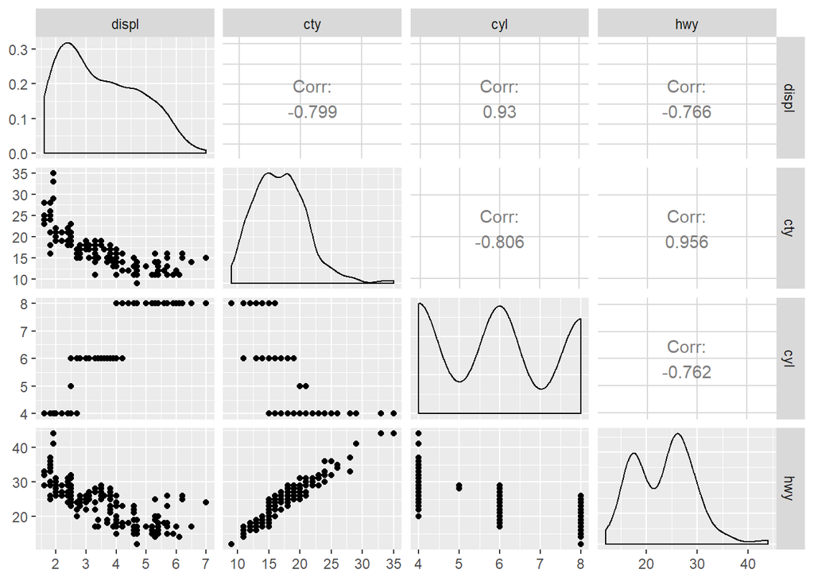

```r
mpg %>%
  select(displ, cty, cyl, hwy) %>%
  ggpairs()
```

Scatterplot matrices are too cluttered for datasets with lots of columns.

The tidyverse way for plotting is to “melt” all the predictor columns into one and to use ggplot with facets:

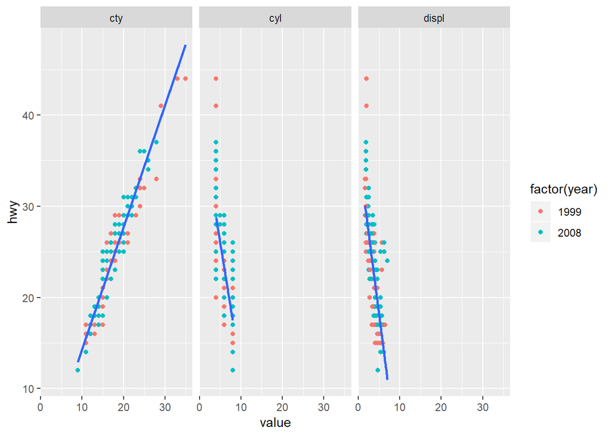

```r
mpg %>%
  select(displ, cty, cyl, year, hwy) %>%
  gather(key = 'parameter', value = 'value', displ:cyl) %>%
  ggplot(mapping = aes(x = value, y = hwy)) +
    geom_point(aes(color = factor(year))) +
    geom_smooth(method = 'lm', se = FALSE) +
    facet_wrap(~ parameter)
```

If you want numerical values of Pearson’s correlation coefficient - use built-in `cor()` function.

It works for any two vectors (columns):

```r
cor(mpg$cty, mpg$hwy)
```

```
## [1] 0.9559159
```

```r
with(mpg, cor(cty, hwy))
```

```
## [1] 0.9559159
```

Or for the entrire table. Note: you should remove all non-numerical and non-relevant columns before using `cor()`.

```r
mpg %>%
  select(displ, cty, cyl, year, hwy) %>%
  cor()
```

```
##            displ         cty        cyl         year          hwy
## displ  1.0000000 -0.79852397  0.9302271  0.147842816 -0.766020021
## cty   -0.7985240  1.00000000 -0.8057714 -0.037232291  0.955915914
## cyl    0.9302271 -0.80577141  1.0000000  0.122245347 -0.761912354
## year   0.1478428 -0.03723229  0.1222453  1.000000000  0.002157643
## hwy   -0.7660200  0.95591591 -0.7619124  0.002157643  1.000000000
```

# The First Model

Use `lm()` to estimate a linear model. The formula notation is used to specify the model’s formula: `y ~ X`

```r
#classical way
m1 <- lm(hwy ~ cty, data = mpg)

#using pipe
m1b <-
  mpg %>%
  lm(hwy ~ cty, data = .)
```

Now the model is stored now in the `m1` variable. Try to devise a clear naming system for your models. It will simplify things a lot when you’ll build many models.

```r
summary(m1)
```

```
##
## Call:
## lm(formula = hwy ~ cty, data = mpg)
##
## Residuals:
##     Min      1Q  Median      3Q     Max
## -5.3408 -1.2790  0.0214  1.0338  4.0461
##
## Coefficients:
##             Estimate Std. Error t value Pr(>|t|)
## (Intercept)  0.89204    0.46895   1.902   0.0584 .
## cty          1.33746    0.02697  49.585   <2e-16 ***
## ---
## Signif. codes:  0 '***' 0.001 '**' 0.01 '*' 0.05 '.' 0.1 ' ' 1
##
## Residual standard error: 1.752 on 232 degrees of freedom
## Multiple R-squared:  0.9138, Adjusted R-squared:  0.9134
## F-statistic:  2459 on 1 and 232 DF,  p-value: < 2.2e-16
```

Compare the model’s residual standard error to the standard deviation of `hwy`:

```r
sd(mpg$hwy)
```

```
## [1] 5.954643
```

We see improvement against the case when no information on the predictor `cty` is used.

How to extract coefficients:

```r
coef(m1)['cty']
```

```
##      cty
## 1.337456
```

You can do so also in text:

The slope coefficient is 1.3374556

# Forecasting

The built-in `predict()` function returns a vector of point forecasts. The `newdata` argument is used to specify the data to apply the model to. This is a regular table, which must contain all the variables used for the model. Just `cty` in our case.

Applying the model to the same data, to get the fitted values:

```r
predict(m1, newdata = mpg) %>% head(10)
```

```
##        1        2        3        4        5        6        7        8
## 24.96624 28.97861 27.64115 28.97861 22.29133 24.96624 24.96624 24.96624
##        9       10
## 22.29133 27.64115
```

Applying the model to new data:

```r
newd <- tibble(cty = c(10, 20, 30))
newd
```

```
## # A tibble: 3 x 1
##     cty
##   <dbl>
## 1    10
## 2    20
## 3    30
```

```r
predict(m1, newdata = newd)
```

```
##        1        2        3
## 14.26660 27.64115 41.01571
```

You can add predictions to the table using `modelr::add_predictions()` function:

```r
newd %>%
  add_predictions(m1)
```

```
## # A tibble: 3 x 2
##     cty  pred
##   <dbl> <dbl>
## 1    10  14.3
## 2    20  27.6
## 3    30  41.0
```

Or, in a classical way, just `cbind()` the vector of predicted values and the original data:

```r
newd %>%
  cbind(predict(m1, newdata = newd))
```

```
##   cty predict(m1, newdata = newd)
## 1  10                    14.26660
## 2  20                    27.64115
## 3  30                    41.01571
```

This is how you can add the interval forecast - the confidence and the prediction intervals:

```r
m1 %>%
  predict(newdata = mpg,
          interval = 'prediction',
          level = .8) %>%
  head()
```

```
##        fit      lwr      upr
## 1 24.96624 22.70903 27.22346
## 2 28.97861 26.71718 31.24004
## 3 27.64115 25.38166 29.90065
## 4 28.97861 26.71718 31.24004
## 5 22.29133 20.03427 24.54840
## 6 24.96624 22.70903 27.22346
```

This is not a table, but a matrix. To use tidyverse’s functions, convert to a table.

```r
confint_m1 <- predict(m1, newdata = mpg,
                      interval = 'confidence',
                      level = .8)   %>%
  as_tibble() %>%
  rename(lci = 'lwr', uci = 'upr')


predint_m1 <- predict(m1, newdata = mpg,
                      interval = 'prediction',
                      level = .8) %>%
  as_tibble() %>%
  rename(lpi = 'lwr', upi = 'upr') %>%
  select(-fit)

forecast_mpg <-
  cbind(mpg, confint_m1, predint_m1)
```

And, finally, plotting the forecast:

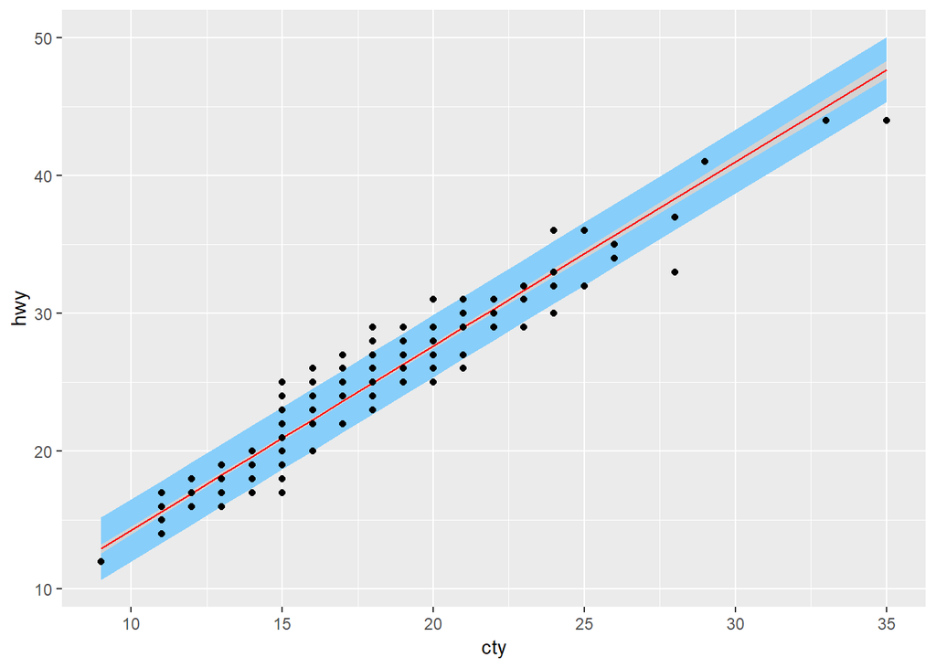

```r
forecast_mpg %>%
  ggplot(aes(x = cty)) +
  geom_ribbon(aes(ymin = lpi, ymax = upi),
              fill = 'lightskyblue') +
  geom_ribbon(aes(ymin = lci, ymax = uci),
              fill = 'lightgray') +
  geom_line(aes(y = fit), color = 'red') +
  geom_point(aes(y = hwy)) +
  ylab('hwy')
```